# Lab 2: Cats vs Dogs

## Part 4. Hyperparameter Search [6 pt]

### Part (a) - 2pt

Based on the plots from above, choose another set of values for the hyperparameters (network, batch_size, learning_rate) that you think would help you improve the validation accuracy. Justify your choice.

```python
'''
Network: 'LargeNet'
--> 'LargeNet' architecture shows better capcacity to model the complex
patterns compared to 'SmallNet', with its deeper layers and greater
number of parameters.

Batchsize: 128
--> 128 is large enough to benefit from the speedups of batch processing
while still providing a reasonably stable estimate of the gradients,
reducing noise compared to smallers batch sizes like 16 or 64, leading
to more stable training and better convergence.

Learning Rate: 0.005
--> This is a compromise choice betweeen the very small learning rates 0.001
and 0.01. A smaller learning rate can help the model converge more smoothly,
ensuring stady progress towards convergence without the risk of the training
process becoming too slow. '''
```

### Part (b) - 1pt

Train the model with the hyperparameters you chose in part(a), and include the training curve.

```
Files already downloaded and verified
Files already downloaded and verified
Epoch 1: Train err: 0.466625, Train loss: 0.6925613274649968 |Validation err: 0.4305, Validation loss: 0.6916250251233578
Epoch 2: Train err: 0.450375, Train loss: 0.6910346604528881 |Validation err: 0.4295, Validation loss: 0.6889703720808029
Epoch 3: Train err: 0.43025, Train loss: 0.6885915559435648 |Validation err: 0.417, Validation loss: 0.6850200556218624
Epoch 4: Train err: 0.43075, Train loss: 0.6850066941881937 |Validation err: 0.4135, Validation loss: 0.6797109991312027
Epoch 5: Train err: 0.421125, Train loss: 0.6813858889398121 |Validation err: 0.4105, Validation loss: 0.6762858554720879
Epoch 6: Train err: 0.41575, Train loss: 0.6772955551980033 |Validation err: 0.4125, Validation loss: 0.6729710213840008
Epoch 7: Train err: 0.40525, Train loss: 0.6732198548695397 |Validation err: 0.406, Validation loss: 0.6695918701589108
Epoch 8: Train err: 0.400625, Train loss: 0.6694106298779684 |Validation err: 0.402, Validation loss: 0.6651057451963425
Epoch 9: Train err: 0.390375, Train loss: 0.6656965234922985 |Validation err: 0.3965, Validation loss: 0.6595603972673416
Epoch 10: Train err: 0.38475, Train loss: 0.6609482859808301 |Validation err: 0.3995, Validation loss: 0.6561327464878559
Epoch 11: Train err: 0.3745, Train loss: 0.6547089446158636 |Validation err: 0.389, Validation loss: 0.6526065990328789
Epoch 12: Train err: 0.379375, Train loss: 0.6502427931815858 |Validation err: 0.3815, Validation loss: 0.644555889070034
Epoch 13: Train err: 0.368, Train loss: 0.6429186813415043 |Validation err: 0.3755, Validation loss: 0.6408654823899269
Epoch 14: Train err: 0.3545, Train loss: 0.6349006607418969 |Validation err: 0.369, Validation loss: 0.6390239223837852
Epoch 15: Train err: 0.3545, Train loss: 0.6318594690353151 |Validation err: 0.387, Validation loss: 0.6491694524884224
Epoch 16: Train err: 0.35075, Train loss: 0.6262631151411269 |Validation err: 0.3565, Validation loss: 0.628677923232317
Epoch 17: Train err: 0.350125, Train loss: 0.6246447080657596 |Validation err: 0.353, Validation loss: 0.6269082017242908
Epoch 18: Train err: 0.343125, Train loss: 0.6182646609487987 |Validation err: 0.3425, Validation loss: 0.6209848523139954
Epoch 19: Train err: 0.336375, Train loss: 0.6113258013649593 |Validation err: 0.3485, Validation loss: 0.6220515631139278
Epoch 20: Train err: 0.33775, Train loss: 0.6074292054252018 |Validation err: 0.3375, Validation loss: 0.6129200533032417
Epoch 21: Train err: 0.329, Train loss: 0.6031468643082513 |Validation err: 0.339, Validation loss: 0.6126730777323246
Epoch 22: Train err: 0.328625, Train loss: 0.5975030670090328 |Validation err: 0.3295, Validation loss: 0.6114750765264034
Epoch 23: Train err: 0.322, Train loss: 0.5931989011310396 |Validation err: 0.324, Validation loss: 0.6026201024651527
Epoch 24: Train err: 0.318, Train loss: 0.5889226595560709 |Validation err: 0.3265, Validation loss: 0.5991240553557873
Epoch 25: Train err: 0.30575, Train loss: 0.5788383200055077 |Validation err: 0.3145, Validation loss: 0.5968427658081055
Epoch 26: Train err: 0.306875, Train loss: 0.5727524052536677 |Validation err: 0.318, Validation loss: 0.5964446403086185
Epoch 27: Train err: 0.302, Train loss: 0.569608471696339 |Validation err: 0.315, Validation loss: 0.5982305780053139
Epoch 28: Train err: 0.3005, Train loss: 0.5655598697208223 |Validation err: 0.335, Validation loss: 0.6148588359355927
Epoch 29: Train err: 0.29175, Train loss: 0.5603908352435581 |Validation err: 0.324, Validation loss: 0.6088103912770748
Epoch 30: Train err: 0.292375, Train loss: 0.5601361673029642 |Validation err: 0.326, Validation loss: 0.604809433221817
Finished Training
Total time elapsed: 791.68 seconds
```

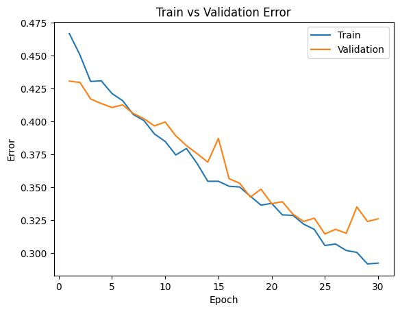

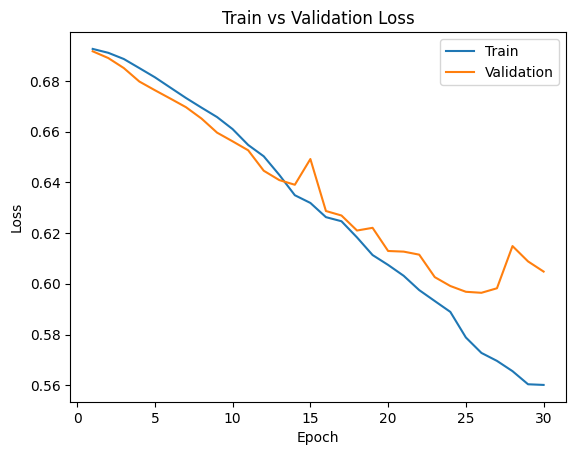

```python
large_net = LargeNet()
train_net(large_net, learning_rate=0.005, batch_size=128)

model_path = get_model_name(large_net.name, 128, 0.005, 29) #assuming 30 epochs
plot_training_curve(model_path)
```

### Part (c) - 2pt

Based on your result from Part(a), suggest another set of hyperparameter values to try. Justify your choice.

```python
'''
Network: LargeNet
--> Continuing with LargeNet because it provides more capacity
for learning complex patterns compared to SmallNet, which is
beneficial for a dataset like CIFAR-10.

Learning Rate: 0.01
--> This can help speed up the convergence, allowing the model to
learn more quickly, especially when the trainng curves from the previous
hyperparameter showed that the model could benefit from a faster
learning rate without becoing unstable.

Batch size: 256
--> This can help in stablizing the training process by providing more
accurate gradient estimates, leading to a better generalization.'''
```

### Part (d) - 1pt

Train the model with the hyperparameters you chose in part(c), and include the training curve.

```
Files already downloaded and verified
Files already downloaded and verified
Epoch 1: Train err: 0.467625, Train loss: 0.6926687750965357 |Validation err: 0.4355, Validation loss: 0.6918838322162628
Epoch 2: Train err: 0.45125, Train loss: 0.6913920938968658 |Validation err: 0.446, Validation loss: 0.6896145716309547
Epoch 3: Train err: 0.4285, Train loss: 0.6892960034310818 |Validation err: 0.418, Validation loss: 0.6862078309059143
Epoch 4: Train err: 0.432625, Train loss: 0.6857281904667616 |Validation err: 0.4185, Validation loss: 0.6810974553227425
Epoch 5: Train err: 0.4265, Train loss: 0.68235875479877 |Validation err: 0.4145, Validation loss: 0.6774234771728516
Epoch 6: Train err: 0.418125, Train loss: 0.6785927079617977 |Validation err: 0.415, Validation loss: 0.6732236221432686
Epoch 7: Train err: 0.408625, Train loss: 0.6743733454495668 |Validation err: 0.412, Validation loss: 0.6696045845746994
Epoch 8: Train err: 0.4015, Train loss: 0.6709288191050291 |Validation err: 0.4015, Validation loss: 0.6678666546940804
Epoch 9: Train err: 0.398125, Train loss: 0.6680959537625313 |Validation err: 0.403, Validation loss: 0.660556748509407
Epoch 10: Train err: 0.389375, Train loss: 0.6634314749389887 |Validation err: 0.3995, Validation loss: 0.658379316329956
Epoch 11: Train err: 0.379625, Train loss: 0.6566815190017223 |Validation err: 0.3855, Validation loss: 0.6529561430215836
Epoch 12: Train err: 0.374875, Train loss: 0.6521265283226967 |Validation err: 0.3855, Validation loss: 0.6488026455044746
Epoch 13: Train err: 0.37425, Train loss: 0.6494845673441887 |Validation err: 0.382, Validation loss: 0.6489764079451561
Epoch 14: Train err: 0.355, Train loss: 0.6393899209797382 |Validation err: 0.3685, Validation loss: 0.6378336399793625
Epoch 15: Train err: 0.359, Train loss: 0.6352421008050442 |Validation err: 0.364, Validation loss: 0.6348829343914986
Epoch 16: Train err: 0.35, Train loss: 0.626285532489419 |Validation err: 0.361, Validation loss: 0.6286248341202736
Epoch 17: Train err: 0.349, Train loss: 0.6286160126328468 |Validation err: 0.3885, Validation loss: 0.6491348221898079
Epoch 18: Train err: 0.345125, Train loss: 0.6229680832475424 |Validation err: 0.357, Validation loss: 0.6288279891014099
Epoch 19: Train err: 0.348375, Train loss: 0.6185612175613642 |Validation err: 0.359, Validation loss: 0.628604456782341
Epoch 20: Train err: 0.33975, Train loss: 0.6089958921074867 |Validation err: 0.347, Validation loss: 0.620079830288887
Epoch 21: Train err: 0.332125, Train loss: 0.6057972330600023 |Validation err: 0.335, Validation loss: 0.616322323679924
Epoch 22: Train err: 0.329125, Train loss: 0.5998155809938908 |Validation err: 0.3325, Validation loss: 0.6092384159564972
Epoch 23: Train err: 0.323, Train loss: 0.5930873621255159 |Validation err: 0.332, Validation loss: 0.6120522990822792
Epoch 24: Train err: 0.325, Train loss: 0.5918655060231686 |Validation err: 0.3375, Validation loss: 0.6046039462089539
Epoch 25: Train err: 0.310125, Train loss: 0.5815890226513147 |Validation err: 0.3235, Validation loss: 0.6006881669163704
Epoch 26: Train err: 0.309125, Train loss: 0.574936468154192 |Validation err: 0.3255, Validation loss: 0.606749102473259
Epoch 27: Train err: 0.299, Train loss: 0.5672708619385958 |Validation err: 0.3195, Validation loss: 0.6002172753214836
Epoch 28: Train err: 0.302375, Train loss: 0.5661260196939111 |Validation err: 0.318, Validation loss: 0.5957315787672997
Epoch 29: Train err: 0.297125, Train loss: 0.5622713100165129 |Validation err: 0.316, Validation loss: 0.6002558171749115
Epoch 30: Train err: 0.298125, Train loss: 0.5677183549851179 |Validation err: 0.322, Validation loss: 0.5977195203304291
Finished Training
Total time elapsed: 768.61 seconds
```

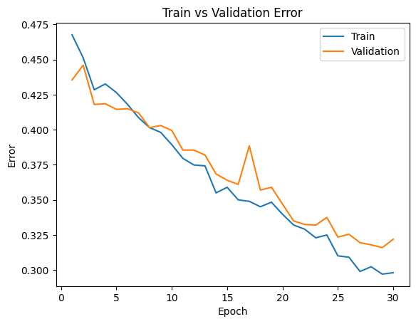

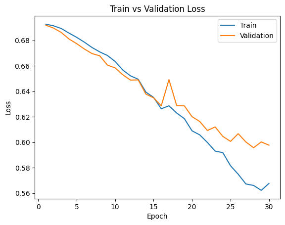

```python
large_net = LargeNet()
train_net(large_net, learning_rate=0.01, batch_size=256)

model_path = get_model_name(large_net.name, 256, 0.01, 29) #assuming 30 epochs
plot_training_curve(model_path)
```